# Analysis on dataset: Leaf

**September 2019, Politecnico di Torino**

**Student: Federico Brignone**

**ID: s253119**

**Professor: Francesco Vaccarino**

```python
import numpy as np
import pandas as pd
import os
import seaborn as sns
import matplotlib.pyplot as plt
import chart_studio.plotly as py
import plotly.graph_objects as go
from chart_studio.plotly import plot, iplot
import cufflinks as cf
cf.set_config_file(offline=False, world_readable=True, theme='ggplot')
from plotly.offline import init_notebook_mode
init_notebook_mode(connected=True)
from sklearn.decomposition import PCA
from sklearn.model_selection import train_test_split, GridSearchCV, cross_val_score
from sklearn.model_selection import learning_curve
from sklearn.neighbors import KNeighborsClassifier
from sklearn.metrics import classification_report, roc_curve, confusion_matrix
from sklearn.metrics import f1_score, accuracy_score, recall_score, precision_score, roc_auc_score, auc
from sklearn.preprocessing import LabelBinarizer, label_binarize
from sklearn.svm import SVC
from sklearn.tree import DecisionTreeClassifier
from sklearn.ensemble import RandomForestClassifier
import warnings
warnings.filterwarnings('ignore')
```

```python
##in this cell, some utility functions e data structires utilized in alaysis...


colors = ['rgb(40, 120, 180)',
          'rgb(255, 125, 340)',
          'rgb(50, 160, 50)',
          'rgb(225, 40, 40)',
          'rgb(148, 110, 195)',
          'rgb(140, 86, 75)',
          'rgb(227, 125, 194)',
          'rgb(127, 200, 127)',
          'rgb(188, 145, 34)',
          'rgb(23, 190, 207)']

#######################################################################################

def conf_matrix(y_test, y_pred):
    labels = {0:1, 1:2, 2:3, 3:4, 4:5, 5:6, 6:7, 7:8, 8:9, 9:10, 10:11, 11:12, 12:13, 13:14, 14:15, 15:22, 16:23, 17:24, 18:25, 19:26, 20:27, 21:28, 22:29, 23:30, 24:31, 25:32, 26:33, 27:34, 28:35, 29:36}
    plt.figure(figsize=(10,9), dpi=200)
    confusion_m = confusion_matrix(y_test, y_pred)
    df_cm = pd.DataFrame(confusion_m)
    df_cm.rename(index=labels, inplace=True)
    df_cm.rename(columns=labels, inplace=True)
    sns.heatmap(df_cm, annot=True)
    plt.ylabel('True label')
    plt.xlabel('Predicted label')
    plt.show()

#######################################################################################

def clf_metrics(title, y_pred, y_true):
    row = []
    print("\n***", title, "scores ***")
    acc = accuracy_score(y_true, y_pred)
    row.append(acc)
    print("Accuracy:\t %.3f" %acc)
    rec = recall_score(y_true, y_pred, average='macro')
    row.append(rec)
    print("Recall:\t\t %.3f" %rec)
    prec = precision_score(y_true, y_pred, average='macro')
    row.append(prec)
    print("Precision:\t %.3f" %prec)
    f1 = f1_score(y_true, y_pred, average='macro')
    row.append(f1)
    print("F1:\t\t %.3f" %f1_score(y_true, y_pred, average='macro'))
    conf_matrix(y_true, y_pred)
    return row

#######################################################################################

# partially based on https://scikit-learn.org/stable/auto_examples/model_selection/plot_learning_curve.html
def plot_learning_curve(estimator, title, X, y, cv=None, n_jobs=-1, train_sizes=np.linspace(.1, 1.0, 5)):
    train_sizes, train_scores, test_scores = learning_curve(
        estimator, X, y, cv=cv, n_jobs=n_jobs, train_sizes=train_sizes, scoring="accuracy", random_state=0)
    train_scores_mean = np.mean(train_scores, axis=1)
    train_scores_std = np.std(train_scores, axis=1)
    test_scores_mean = np.mean(test_scores, axis=1)
    test_scores_std = np.std(test_scores, axis=1)

    trace1 = go.Scatter(
        x=train_sizes,
        y=train_scores_mean - train_scores_std,
        showlegend=False,
        mode="lines",
        name="",
        hoverlabel = dict(
            namelength=20
        ),
        line = dict(
            width = 0.1,
            color = get_color_with_opacity(colors[0], 0.4),
        ),
    )
    trace2 = go.Scatter(
        x=train_sizes,
        y=train_scores_mean + train_scores_std,
        showlegend=False,
        fill="tonexty",
        mode="lines",
        name="",
        hoverlabel = dict(
            namelength=20
        ),
        line = dict(
            width = 0.1,
            color = get_color_with_opacity(colors[0], 0.4),
        ),
    )
    trace3 = go.Scatter(
        x=train_sizes,
        y=train_scores_mean,
        showlegend=True,
        name="Training score",
        line = dict(
            color = colors[0],
        ),
    )

    trace4 = go.Scatter(
        x=train_sizes,
        y=test_scores_mean - test_scores_std,
        showlegend=False,
        mode="lines",
        name="",
        hoverlabel = dict(
            namelength=20
        ),
        line = dict(
            width = 0.1,
            color = get_color_with_opacity(colors[1], 0.4),
        ),
    )
    trace5 = go.Scatter(
        x=train_sizes,
        y=test_scores_mean + test_scores_std,
        showlegend=False,
        fill="tonexty",
        mode="lines",
        name="",
        hoverlabel = dict(
            namelength=20
        ),
        line = dict(
            width = 0.1,
            color = get_color_with_opacity(colors[1], 0.4),
        ),
    )
    trace6 = go.Scatter(
        x=train_sizes,
        y=test_scores_mean,
        showlegend=True,
        name="Cross-validation score",
        line = dict(
            color = colors[1],
        ),
    )

    data = [trace1, trace2, trace3, trace4, trace5, trace6]
    layout = go.Layout(
        title=title,
        autosize=True,
        yaxis=dict(
            title='Score',
        ),
        xaxis=dict(
            title="Training samples",
        ),
        legend=dict(
            x=0.8,
            y=0,
        ),
    )
    fig = go.Figure(data=data, layout=layout)
    fig.show()

def get_color_with_opacity(color, opacity):
    return "rgba(" + color[4:-1] + ", %.2f)" % opacity
#######################################################################################
```

### Introduction

In this analysis our aim will be to analyze a dataset of leaves.  
The dataset can be found here: https://archive.ics.uci.edu/ml/datasets/leaf  
For this analysis we will use Jupyter Notebook, a server-client application that allows editing and running notebook documents via a web browser.  
Our Python version will be 3.7.  
Below the libraries that we will use:

- numpy: a fundamental package for scientific computing with Python. It manages N-dimensional array object and useful linear algebra, Fourier transform, and random number capabilities
- pandas: library containing advanced structures to manage data
- matplotlib: library for making graphs
- plotly: library for making interactive charts
- sklearn: library containing the main algorithms of machine learning

### Dataset description and visualization

In this dataset we have data describing the shape of the leaves of 40 different types of plant, but only 30 types are simple enough to be processed and transformed.  
Each leaf specimen was photographed over a coloured background using an Apple iPAD 2 device. The 24-bit RGB images the images were then processed, so that each leaf is described by 16 different attributes.

[figure not shown]

#### Attributes:

Let $I$ denote an object of interest in a binary image, $\partial I$ its border, $D(I)$ its diameter, i.e., the maximum distance between any two points in $\partial I$ and $A(I)$ its area. Let $A(H(I))$ denote the area of the object's convex hull (i.e. any 'optimal' inscribing convex polygon) and $L(\partial I)$ the object's contour length. Assume that the operator $d(.)$ stands for the Euclidean distance.  
Moreover, if $Z$ is a random variable indicating image intensity, its $n$th moment around the mean is $\mu_{n}=\sum_{i=0}^{L-1}\left(z_{i}-m\right)^{n} p\left(z_{i}\right)$, where $m$ is the mean of $Z$, $p(.)$ its histogram and $L$ is the number of intensity levels.

- *Class*: integer corresponding to a class
- *Specimen number*: the number of element belonging to the class
- *Eccentricity*: Eccentricity of the ellipse with identical second moments to $I$. This value ranges from 0 to 1
- *Aspect ratio*: Consider any $X, Y \in \partial I$. Choose $X$ and $Y$ such that $d(X; Y ) = D(I)$. Find $Z, W \in \partial I$ maximizing $D^{\perp} = d(Z,W)$ on the set of all pairs of $\partial I$ that define a segment orthogonal to $[XY]$. The aspect ratio is defined as the quotient $D(I)/D^\perp$ Values close to 0 indicate an elongated shape
- *Elongation*: Compute the maximum escape distance $d_{\max } = \max _{X \in I} d(X, \partial I)$. Elongation is obtained as $1-2 d_{\max } / D(I)$ and ranges from 0 to 1. The minimum is achieved for a circular region. Note that the ratio $2 d_{\max } / D(I)$ is the quotient between the diameter of the largest inscribed circle and the diameter of the smallest circumscribed circle
- *Solidity*: The ratio $A(I)/A(H(I))$ is computed, which can be understood as a certain measure of convexity. It measures how well $I$ fits a convex shape
- *Stochastic convexity*: This variable extends the usual notion of convexity in topological sense, using sampling to perform the calculation. The aim is to estimate the probability of a random segment $[XY]$, $X,Y \in I$, to be fully contained in $I$
- *Isoperimetric factor*: The ratio 4$\pi A(I) / L(\partial I)^{2}$ is calculated. The maximum value of 1 is reached for a circular region. Curvy intertwined contours yield low values
- *Maximal indentation depth*: Let $C _{H(I)}$ and $L(H(I))$ denote the centroid and arclength of $H(I)$. The distances $d(X;C_{H(I)})$ and $d(Y;C_{H(I)})$ are computed $\forall X \in H(I)$ and $\forall Y \in \partial I$. The indentation function can then be defined as $\left[d\left(X, C_{H(I)}\right)-d\left(Y, C_{H(I)}\right)\right] / L(H(I))$, which is sampled at one degree intervals. The maximal indentation depth $\mathfrak{D}$ is the maximum of this function
- *Lobedness*: The Fourier Transform of the indentation function above is computed after mean removal. The resulting spectrum is normalized by the total energy. Calculate lobedness as $F \times \mathfrak{D}^2$, where $F$ stands for the smallest frequency at which the cumulated energy exceeds 80%. This feature characterizes how lobed a leaf is
- *Average Intensity*: Average intensity is de ned as the mean of the intensity image, $m$
- *Average contrast*: Average contrast is the the standard deviation of the intensity image, $\sigma=\sqrt{\mu_{2}(z)}$
- *Smoothness*: Smoothness is defined as $R=1-1 /\left(1+\sigma^{2}\right)$ and measures the relative smoothness of the intensities in a given region. For a region of constant intensity, $R$ takes the value 0 and $R$ approaches 1 as regions exhibit larger disparities in intensity values. $\mu^2$ is generally normalized by $(L-1)^2$ to ensure that $R \in [0; 1]$
- *Third moment*: $\mu_3$ is a measure of the intensity histogram's skewness. This measure is generally normalized by $(L-1)^2$ like smoothness
- *Uniformity*: Defined as $U=\sum_{i=0}^{L-1} p^{2}\left(z_{i}\right)$, uniformity's maximum value is reached when all intensity levels are equal
- *Entropy*: A measure of intensity randomness

```python
features = ['Class', 'Specimen Number', 'Eccentricity', 'Aspect Ratio', 'Elongation', 'Solidity', 'Stochastic Convexity', 'Isoperimetric Factor', 'Maximal Indentation Depth', 'Lobedness', 'Average Intensity', 'Average Contrast', 'Smoothness', 'Third Moment', 'Uniformity', 'Entropy']
leaf = pd.read_csv("leaf.csv", header=None, names=features)
```

```python
# Checking if there are null values
if (leaf.isnull().sum().max() == 0):
    print("\nNo null values")
```

```
No null values
```

Using the Pandas *describe* function, we can see for each attribute:

- count: number of samples
- mean: the mean value
- std: the standard deviation
- min: the minimum value
- 25%: the first quartile
- 50%: the median value (the second quartile)
- 75%: the third quartile
- max: the maximum value

```python
leaf.describe()
```

|  | Class | Specimen Number | Eccentricity | Aspect Ratio | Elongation | Solidity | Stochastic Convexity | Isoperimetric Factor | Maximal Indentation Depth | Lobedness | Average Intensity | Average Contrast | Smoothness | Third Moment | Uniformity | Entropy |
| --- | --- | --- | --- | --- | --- | --- | --- | --- | --- | --- | --- | --- | --- | --- | --- | --- |
| count | 340.000000 | 340.000000 | 340.000000 | 340.000000 | 340.000000 | 340.000000 | 340.000000 | 340.000000 | 340.000000 | 340.000000 | 340.000000 | 340.000000 | 340.000000 | 340.000000 | 340.000000 | 340.000000 |
| mean | 18.544118 | 6.282353 | 0.719854 | 2.440210 | 0.513760 | 0.904158 | 0.943793 | 0.531234 | 0.037345 | 0.523845 | 0.051346 | 0.124535 | 0.017670 | 0.005928 | 0.000387 | 1.162630 |
| std | 11.152514 | 3.462779 | 0.208311 | 2.599043 | 0.195583 | 0.114639 | 0.115047 | 0.217532 | 0.038575 | 1.039639 | 0.035965 | 0.051860 | 0.013755 | 0.005294 | 0.000431 | 0.584854 |
| min | 1.000000 | 1.000000 | 0.117080 | 1.006600 | 0.107610 | 0.485490 | 0.396490 | 0.078376 | 0.002837 | 0.001464 | 0.005022 | 0.033415 | 0.001115 | 0.000229 | 0.000007 | 0.169400 |
| 25% | 9.000000 | 3.000000 | 0.550622 | 1.211300 | 0.349623 | 0.890667 | 0.966230 | 0.346818 | 0.009521 | 0.016500 | 0.022843 | 0.083362 | 0.006901 | 0.002080 | 0.000102 | 0.718900 |
| 50% | 15.000000 | 6.000000 | 0.763450 | 1.570750 | 0.501855 | 0.948130 | 0.992980 | 0.579160 | 0.023860 | 0.103615 | 0.042087 | 0.119375 | 0.014050 | 0.004447 | 0.000239 | 1.077450 |
| 75% | 29.000000 | 9.000000 | 0.895097 | 2.343100 | 0.633373 | 0.976897 | 1.000000 | 0.700712 | 0.047834 | 0.416433 | 0.073046 | 0.163795 | 0.026127 | 0.008307 | 0.000516 | 1.554575 |
| max | 36.000000 | 16.000000 | 0.998710 | 19.038000 | 0.948340 | 0.993880 | 1.000000 | 0.858160 | 0.198980 | 7.206200 | 0.190670 | 0.280810 | 0.073089 | 0.029786 | 0.002936 | 2.708500 |

Now, we want observe the distribution of data over classes, in order to find if our dataset is balanced.

```python
quantities = leaf['Class'].value_counts(sort=False)

for i in quantities.index.values:
    print('Class #'+str(i)+":\t", round(quantities[i]/len(leaf)*100, 2), '% of the dataset')
```

```
Class #1:	 3.53 % of the dataset
Class #2:	 2.94 % of the dataset
Class #3:	 2.94 % of the dataset
Class #4:	 2.35 % of the dataset
Class #5:	 3.53 % of the dataset
Class #6:	 2.35 % of the dataset
Class #7:	 2.94 % of the dataset
Class #8:	 3.24 % of the dataset
Class #9:	 4.12 % of the dataset
Class #10:	 3.82 % of the dataset
Class #11:	 4.71 % of the dataset
Class #12:	 3.53 % of the dataset
Class #13:	 3.82 % of the dataset
Class #14:	 3.53 % of the dataset
Class #15:	 2.94 % of the dataset
Class #22:	 3.53 % of the dataset
Class #23:	 3.24 % of the dataset
Class #24:	 3.82 % of the dataset
Class #25:	 2.65 % of the dataset
Class #26:	 3.53 % of the dataset
Class #27:	 3.24 % of the dataset
Class #28:	 3.53 % of the dataset
Class #29:	 3.53 % of the dataset
Class #30:	 3.53 % of the dataset
Class #31:	 3.24 % of the dataset
Class #32:	 3.24 % of the dataset
Class #33:	 3.24 % of the dataset
Class #34:	 3.24 % of the dataset
Class #35:	 3.24 % of the dataset
Class #36:	 2.94 % of the dataset
```

In order to better understand the data, we will do some plots, to better visualize the data.

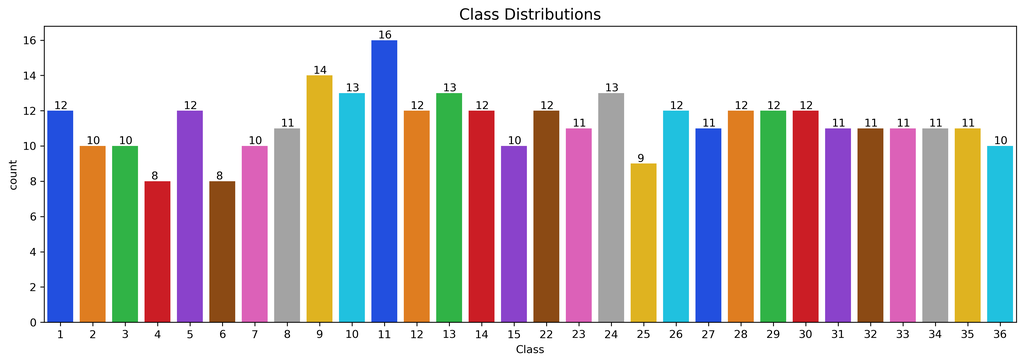

```python
plt.figure(figsize=(16,5), dpi=300)
ax = sns.countplot('Class', data=leaf, palette='bright')
plt.title('Class Distributions', fontsize=14)

for p, i in zip(ax.patches, quantities.index.values):
    ax.annotate('{:.0f}'.format(quantities[i]), (p.get_x()+0.2, p.get_height()+0.1))

plt.show()
```

We can see that our dataset is balanced.  
The minimum number of species in each class is 8 (for classes #4 and #6), the maximum number is 16 in class #11.

```python
leaf['Class'].unique()
```

```
array([ 1,  2,  3,  4,  5,  6,  7,  8,  9, 10, 11, 12, 13, 14, 15, 22, 23,
       24, 25, 26, 27, 28, 29, 30, 31, 32, 33, 34, 35, 36], dtype=int64)
```

We observe that we have 30 different classes, numerated from #1 to #15, and from #22 to #36.

Now, we want observe how the different attributes are distributed over each class.  
To visualize this information, we can use the box-plot.

A **box-plot** displays the five-number summary of a set of data. The five numbers are: the minimum, first quartile, median, third quartile, and maximum. The five-number summary divides the data into sections that each contain approximately 25% of the data in that set. In a box-plot, we draw a box from the first quartile to the third quartile. A vertical line goes through the box at the median. The whiskers go from each quartile to the minimum or maximum.  
The "interquartile range", abbreviated $IQR$, is just the width of the box in the box-and-whisker plot. That is, $IQR = Q3 – Q1$ . The $IQR$ can be used as a measure of how spread-out the values are. That is, if a data point is below $Q1 – 1.5×IQR$ or above $Q3 + 1.5×IQR$, it is viewed as being too far from the central values to be reasonable.

[figure not shown]

```python
#boxplot
layout = go.Layout(height=900)

# Create figure
fig = go.Figure(layout = layout)

# Add traces, one for each slider step
for f_select in features[2:]:
    #print("feature_selected:", f_select)
    for curr_class in leaf['Class'].unique():
        temp_data = leaf.loc[leaf['Class'] == curr_class]
        fig.add_trace(
            go.Box(visible=False,
                y=temp_data[f_select].values,
                name = 'Class #' + str(curr_class)
            )
        )

# Make first 30 traces visible
for i in range(30):
    fig.data[i].visible = True

# Create and add slider
steps = []
for f_select in range(len(features)-2):
    step = dict(
        method="restyle",
        args=["visible", [False] * len(fig.data)],
        label = features[f_select+2]
    )
    base=f_select*30
    for i in range(30):
        step["args"][1][base + i] = True  # Toggle i'th trace to "visible"
    steps.append(step)

sliders = [dict(
    active=0,
    currentvalue={"prefix": "Attribute: "},
    pad={"t": 50},
    steps=steps
)]

fig.update_layout(
    sliders=sliders
)
fig.update_xaxes(tickangle=45)
fig.show()
```

[interactive chart not shown]

Looking at the distribution of attributes for each class in box-plots, we can see that for some attributes the distributions are almost the same along the classes (e.g. *Aspect Ratio* and *Stochastic Convexity*), while for other attributes the distributions vary a lot from class to class (e.g. *Entropy* and *Elongation*).

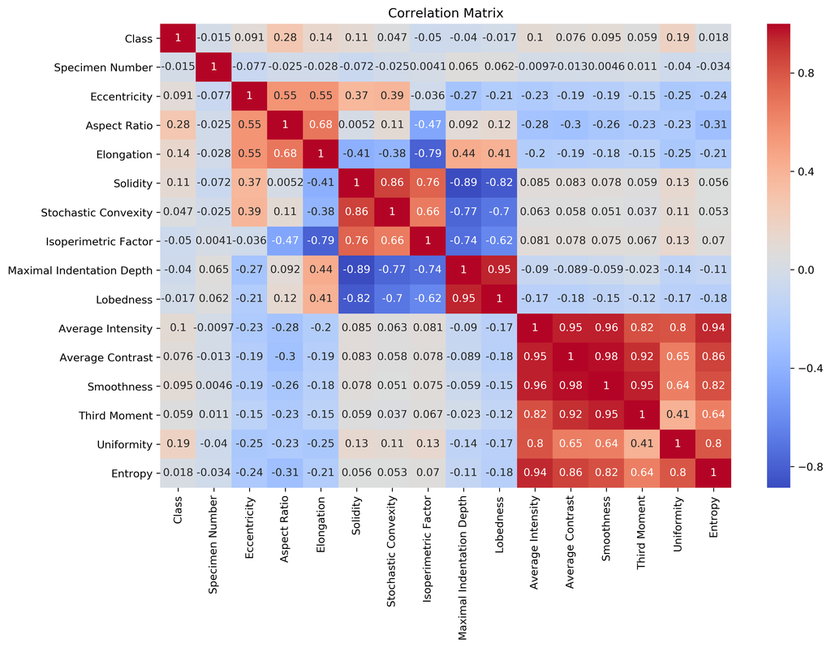

```python
#Correlation Matrix
f, ax1 = plt.subplots(1, 1, figsize=(12,8), dpi=300)

corr = leaf.corr()
sns.heatmap(corr, cmap='coolwarm', annot=True, ax=ax1)
ax1.set_title("Correlation Matrix")
#ax1.set_xticklabels(ax1.get_xticklabels(),rotation=60, x=0.5)
plt.show()
```

From the correlation matrix we can see that there is a strong positive correlation between the attributes: *Average Intensity*, *Average Contrast*, *Smoothness*, *Third Moment*, *Uniformity*, *Entropy*.  
Other attributes positively correlated are: Also *Maximal indentation Depth* and *Lobedness*, *Stochastic Convexity*, *Solidity* and *Isoperimetric Factor*.  
Last but not least, there is a negative correlation between the attributes: *Maximal Indentation Depth* and *Lobedness* with *Solidity*, *Stochastic Convexity* and *Isoperimetric Factor*.  
All these strong correlations between different attributes lead us to think that the dimensionality of our data can be reduced. We will see if our intuitions will be confirmed by the Principal Component Analysis.

$$ Z = \frac{X-\mu}{\theta} $$

After standardization, we will apply the **Principal Component Analysis**, known also as PCA. Principal component analysis is a statistical procedure that uses an orthogonal transformation to convert a set of observations of possibly correlated variables (entities each of which takes on various numerical values) into a set of values of linearly uncorrelated variables called principal components. This transformation is defined in such a way that the first principal component has the largest possible variance, and each succeeding component in turn has the highest variance possible under the constraint that it is orthogonal to the preceding components. The resulting vectors (each being a linear combination of the variables and containing n observations) are an uncorrelated orthogonal basis set.  
This technique can be used to reduce the dimensionality of the dataset while preserving the information in the databy considering just the most important principal components or as exploratory data analysis tool.

We can perform PCA in 5 steps:

- Standardize the data, obtaining $X$
- Compute the covariance matrix $S = Cov(X)$
- Compute the eigenvectors and the eigenvalues of the covariance matrix
- Choose principal components: eigenvectors are ordered by eigenvalues from the highest to the lowest. The $k$ chosen eigenvectors will be the number of dimensions of the new dataset. We obtain a $d$ x $k$ eigenvector matrix $W$, whose columns are the eigenvectors of $S$
- Compute the new dataset $ X' = XW $

Now, let's apply PCA to our data

```python
#PCA
#remove Class and Specimen Number
leaf_X = leaf.drop(['Class', 'Specimen Number'], axis=1)
leaf_y = leaf['Class']
#standardization
leaf_Xstd = (leaf_X - leaf_X.mean())/leaf_X.std()
pca = PCA()
leaf_X_pca = pca.fit_transform(leaf_Xstd)

pippo = go.Figure()
pca_variance = go.Scatter(x=list(range(1, len(pca.components_ )+1)),
                                 y=pca.explained_variance_ratio_.cumsum()*100,
                                 mode='lines+markers',
                                 name='PCA variance')
pippo.add_trace(pca_variance)
pippo.update_layout(
    xaxis=go.layout.XAxis(
        title=go.layout.xaxis.Title(text="Number of principal components")
    ),
    yaxis=go.layout.YAxis(
        title=go.layout.yaxis.Title(text="Explained variance (%)")
    ))
pippo.show()
```

[interactive chart not shown]

We can see that the first two principal components express the 70,5% of the total variance, and **the first three principal components** express about **85,6% of the total variance**. This confirms our insights after noticing that many attributes of the dataset had strong correlations between them.  
So, we could decide to use only the first three pricipal components to compute a dimensionally reduced dataset.

```python
W = pca.components_[:,:3]
leaf_X_reduced = leaf_Xstd.dot(W)
leaf_X_reduced.shape
```

```
(340, 3)
```

### Classification

Now, we can process our data and train various classifiers and study their behavior.  
Since our data is relatively small, we need to make the most of it to train our classifiers, but we also need a portion of data for the test set, and another portion for the validation set, a set used as a test set, but used in the grid search, the operation dedicated to fine-tuning the classifier's hyperparameters. **k-Fold Cross Validation** comes to our rescue.

A test set should still be kept out for final evaluation, but the validation set is no longer needed when making the Cross Validation. In the basic approach, called k-fold cross validation, the training set is divided into smaller k sets. The following procedure is adopted for each of the k “folds”:

- a model is trained using $K - 1$ folds as training data
- the resulting model is validated on the remaining fold

The performance measure reported by k-fold cross-validation is then the average of the values computed in the loop. This approach can be computationally expensive, but does not waste too much data, which is a major advantage in problems such as inverse inference where the number of samples is very small.

[figure not shown]

Now, we define **some metrics used to model evaluation**. We will use them, when we train some models. These measures are made to evaluate the quality of the classification for each class. In our study, having 30 different classes, we will focus only on the average value, after calculating the measurements for each class.

$$ accuracy = \frac{number\space of\space correctly\space classified\space objects}{number\space of\space classified\space objects} $$

$$ recall = \frac{number\space of\space objects\space correctly\space assigned\space to\space C}{number\space of\space objects\space belonging\space to\space C} $$

$$ precision = \frac{number\space of\space objects\space correctly\space assigned\space to\space C}{number\space of\space objects\space assigned\space to\space C} $$

$$ F-measure = \frac{2 r p}{r\space +\space p} $$

To study our models, we will also use two other tools: the confusion matrix and the learning curve.

[figure not shown]

Finally, the **learning curve** shows the validation and training score of an estimator for varying numbers of training samples. It is a tool to find out how much we benefit from adding more training data and whether the estimator suffers more from a variance error or a bias error. If both the validation score and the training score converge to a value that is too low with increasing size of the training set, we will not benefit much from more training data.

[figure not shown]

```python
X_train, X_test, y_train, y_test = train_test_split(
    leaf_Xstd, leaf_y, test_size=0.2, stratify=leaf_y, random_state=0)

X_train_red, X_test_red, y_train_red, y_test_red = train_test_split(
    leaf_X_reduced, leaf_y, test_size=0.2, stratify=leaf_y, random_state=0)
```

#### $k$-Nearest Neighbor

The first classifier we will train on our data will be the $k$-Nearest Neighbor.

The $k$-NN is a supervised machine learning algorithm, based on the calculation of distances between objects.  
An object is classified by a plurality vote of its neighbors, with the object being assigned to the class most common among its $k$ nearest neighbors ($k$ is a positive integer, typically small). If $k = 1$, then the object is simply assigned to the class of that single nearest neighbor.  
A possible variation of the algorithm consists in assigning weights to the contributions of the neighbors, so that the nearer neighbors contribute more to the average than the more distant ones.

Steps to perform the $k$-NN Algorithm:

1. Load the data
2. Initialize $k$ to your chosen number of neighbors
3. For each example in the data:
   - Calculate the distance between the query example and the current example from the data
   - Add the distance and the index of the example to an ordered collection
4. Sort the ordered collection of distances and indices from smallest to largest (in ascending order) by the distances
5. Pick the first $k$ entries from the sorted collection
6. Get the labels of the selected $k$ entries
7. Return the mode of the $k$ labels

```python
knn_parameters = {
    'n_neighbors' : [1, 2, 5, 10, 15, 20, 30],
    'weights' : ['uniform', 'distance'],
    'p' : [1,2,5,10] #power parameter for the Minkowski metric
}
```

```
Best parameters found: {'n_neighbors': 1, 'p': 1, 'weights': 'uniform'}

*** KNN scores ***
Accuracy:	 0.706
Recall:		 0.711
Precision:	 0.753
F1:		 0.704
```

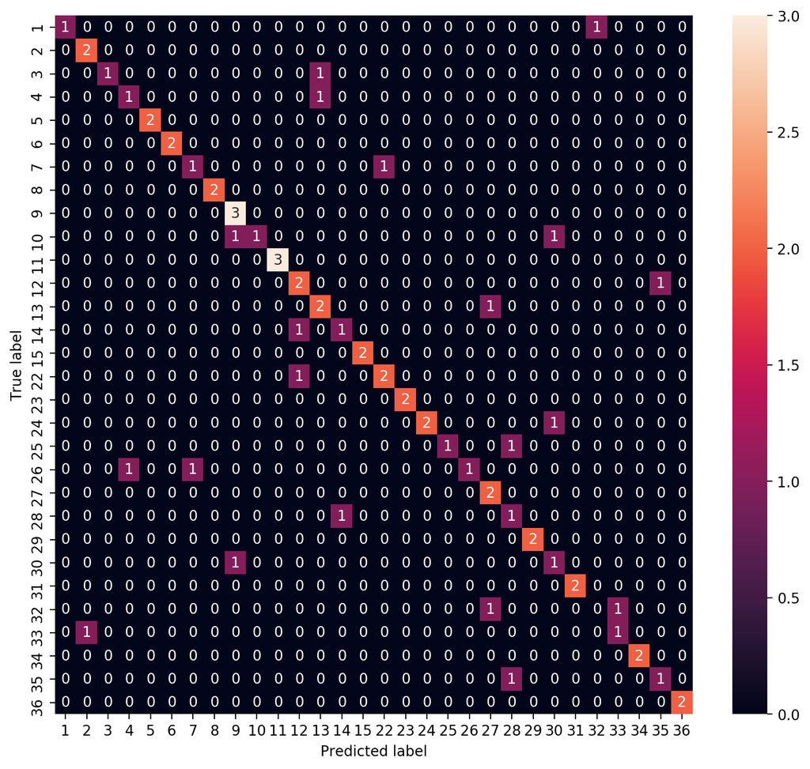

```python
clf_knn = GridSearchCV(KNeighborsClassifier(), knn_parameters, cv=5, iid=True)
clf_knn.fit(X_train, y_train)
clf_knn.cv_results_['mean_test_score']

'''means = clf_knn.cv_results_['mean_test_score']
stds = clf_knn.cv_results_['std_test_score']
for mean, std, params in zip(means, stds, clf_knn.cv_results_['params']):
        print("%0.3f (+/-%0.03f) for %r"
              % (mean, std * 2, params))'''

print("\nBest parameters found:", clf_knn.best_params_)
#score on test set
#print(clf_knn.score(X_test, y_test))
results_knn = clf_metrics("KNN", clf_knn.predict(X_test), y_test)
```

```python
title = "Learning Curve, KNN, " + str(clf_knn.best_params_)
plot_learning_curve(clf_knn.best_estimator_, title, leaf_Xstd, leaf_y, cv=5)
```

[interactive chart not shown]

This learning curve lets us think that having a larger training set, the accuracy of the model would be increased.

```
Best parameters found: {'n_neighbors': 5, 'p': 2, 'weights': 'distance'}

*** KNN with dimensionally reduced dataset scores ***
Accuracy:	 0.382
Recall:		 0.406
Precision:	 0.386
F1:		 0.369
```

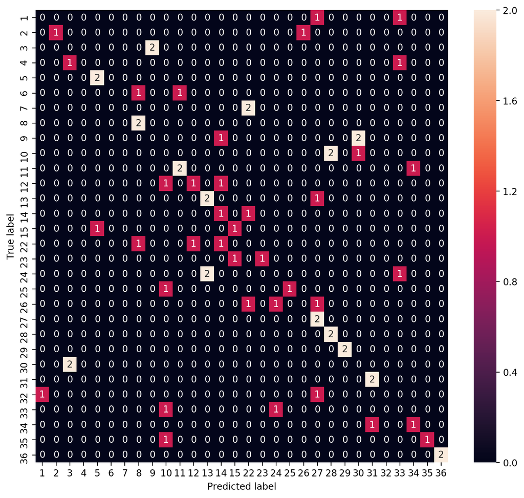

```
[0.38235294117647056,
 0.40555555555555556,
 0.38611111111111107,
 0.369047619047619]
```

```python
#now we'll use the dataset dimensionally reduced

clf_knn2 = GridSearchCV(KNeighborsClassifier(), knn_parameters, cv=5, iid=True)
clf_knn2.fit(X_train_red, y_train_red)
print("\nBest parameters found:", clf_knn2.best_params_)
clf_knn2.cv_results_['mean_test_score']


'''means = clf_knn2.cv_results_['mean_test_score']
stds = clf_knn2.cv_results_['std_test_score']
for mean, std, params in zip(means, stds, clf_knn2.cv_results_['params']):
        print("%0.3f (+/-%0.03f) for %r"
              % (mean, std * 2, params))'''

#score on test set
clf_knn2.score(X_test_red, y_test_red)
clf_metrics("KNN with dimensionally reduced dataset", clf_knn2.predict(X_test_red), y_test_red)
```

We can see that using the dimensionally reduced training set, the accuracy of the model decreases a lot. Probably, with so little data even that small amount of lost variance was important for training.

```python
title = "Learning Curve, KNN with dimensionally reduced dataset, " + str(clf_knn2.best_params_)
plot_learning_curve(clf_knn2.best_estimator_, title, leaf_Xstd, leaf_y, cv=5)
```

[interactive chart not shown]

#### Support Vector Machine

Now, let's see what happens using the SVM classifier.

The **Support Vector Machine** (SVM) is a supervised machine learning algorithm, based on research of the hyperplane that better divides two classes of data (is therefore an optimization problem).  
In case you want to solve a non-linear problem, you can map the data to a different space or a larger size through a kernel.  
It is also possible to use the algorithm for a multiclass problem ($N>2$), adopting two possible strategies:

- OVO (One versus one): in this case, $N$ classifiers will be trained, each of which will consider one class against all the others
- OVA (One versus all): in this other case, ${N}\choose{2}$ pairwise classifiers will be trained; each pair of classifiers receives the samples of a pair of classes from the original training set, and must learn to distinguish these two classes. Trined all classifiers, an element will be assigned to the class that wins the most pairwise competitions

[figure not shown]

```python
svm_parameters = {
    'gamma' : [1e-5, 1e-3, 1e-2, 1e-1, 1e1, 1e2, 1e3],
    'kernel' : ['rbf', 'poly', 'linear', 'sigmoid'],
    'C' : [0.01, 0.1, 1, 10, 100, 10000],
    'decision_function_shape' : ['ovo', 'ovr']
}
```

```
Best parameters found: {'C': 100, 'decision_function_shape': 'ovo', 'gamma': 0.01, 'kernel': 'rbf'}

*** SVM scores ***
Accuracy:	 0.882
Recall:		 0.900
Precision:	 0.878
F1:		 0.874
```

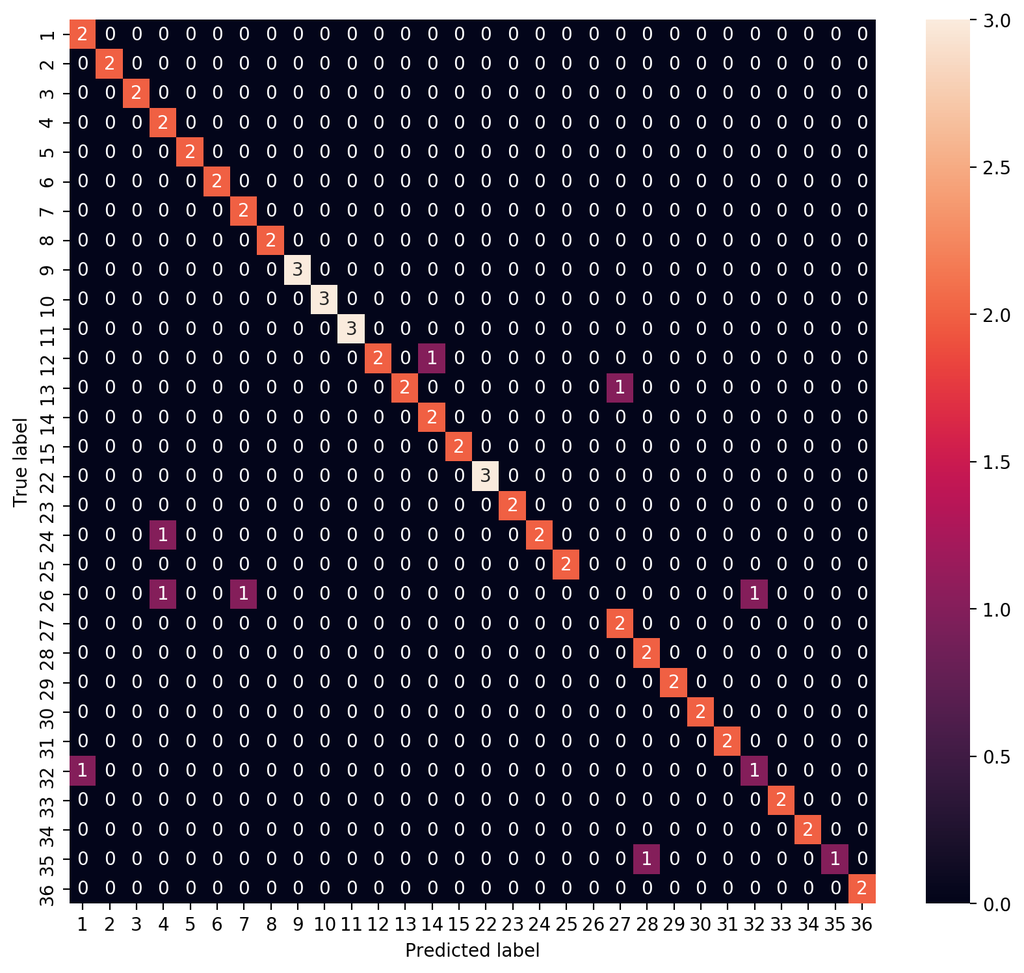

```python
clf_svm = GridSearchCV(SVC(), svm_parameters, cv=5, iid=True)
clf_svm.fit(X_train, y_train)

'''means = clf_svm.cv_results_['mean_test_score']
stds = clf_svm.cv_results_['std_test_score']
for mean, std, params in zip(means, stds, clf_svm.cv_results_['params']):
        print("%0.3f (+/-%0.03f) for %r"
              % (mean, std * 2, params))'''

print("\nBest parameters found:", clf_svm.best_params_)
#computing score on test set
results_svm = clf_metrics("SVM", clf_svm.predict(X_test), y_test)
```

```python
title = "Learning Curve, SVM, " + str(clf_svm.best_params_)
plot_learning_curve(clf_svm.best_estimator_, title, leaf_Xstd, leaf_y, cv=5)
```

[interactive chart not shown]

This learning curve lets us think that, by increasing the number of elements in the training set, the accuracy of the classifier would increase. Unlike the learning curves seen above for $k$-NN classifier, here we also guess that the accuracy of the classifier would be upper bounded.

```python
####CELLA ETERNA

'''clf_svm2 = GridSearchCV(SVC(), svm_parameters, cv=5, iid=True)
clf_svm2.fit(X_train_red, y_train_red)

means = clf_svm2.cv_results_['mean_test_score']
stds = clf_svm2.cv_results_['std_test_score']
for mean, std, params in zip(means, stds, clf_svm2.cv_results_['params']):
        print("%0.3f (+/-%0.03f) for %r"
              % (mean, std * 2, params))

print("\nBest parameters found:", clf_svm2.best_params_)
#computing score on test set
clf_metrics("SVM with dimensionally reduced dataset", clf_svm2.predict(X_test_red), y_test_red)'''
```

[output not shown]

#### Decision tree

A **Decision tree** used for classification, is a supervised machine learning algorithm that that allows the construction of a tree. Due to a computional limit, the building of the tree is done using a top-down greedy approach: at each step, we search the best split from which two new branches are generated.  
To find the best split different metrics can be used. In this analysis, we will use the two metrics below (both measure the *node purity*):

- Gini index: $\;I_G(p) = 1- \sum_{i=1}^j {p_i}^2$ where:
  - $j$: number of classes
  - $p_i$: fraction of items of class $i$ in a subset $p$, $i \in \{1,2,..., j\}$
- Entropy (in order to measure the information gain): reduction of entropy applying the split. Defined as $H(t) = - \sum_{i=1}^j p_i\, \text{log}_2\,p_i$

[figure not shown]

Let's build our model.

```python
dtree_parameters = {
    'criterion': ['gini', 'entropy'],
    'max_depth': [25, 50, 75, 100],
    'max_features': ["sqrt", "log2", None],
    'max_leaf_nodes' : [30, 60, 120, 500]
    #'min_samples_split': [6, 10, 14],
}
```

```
Best parameters found: {'criterion': 'gini', 'max_depth': 25, 'max_features': 'sqrt', 'max_leaf_nodes': 120}

*** Decision tree scores ***
Accuracy:	 0.647
Recall:		 0.656
Precision:	 0.614
F1:		 0.613
```

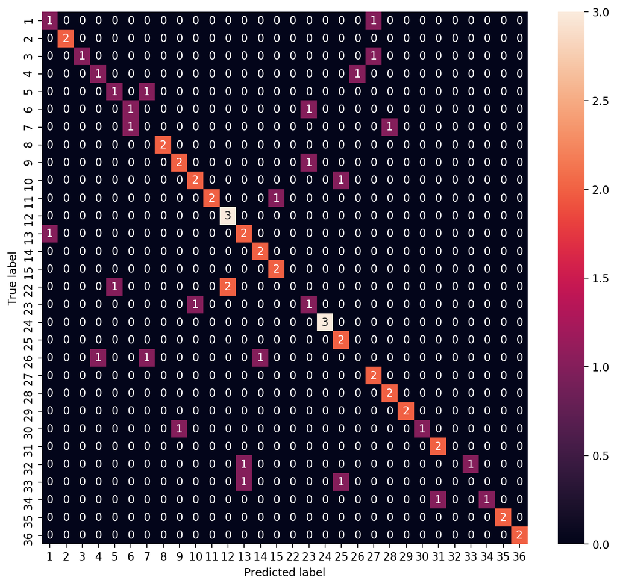

```python
clf_dtree = GridSearchCV(DecisionTreeClassifier(), dtree_parameters, cv=5, iid=True)
clf_dtree.fit(X_train, y_train)

'''means = clf_svm.cv_results_['mean_test_score']
stds = clf_svm.cv_results_['std_test_score']
for mean, std, params in zip(means, stds, clf_svm.cv_results_['params']):
        print("%0.3f (+/-%0.03f) for %r"
              % (mean, std * 2, params))'''

print("\nBest parameters found:", clf_dtree.best_params_)
#computing score on test set
results_dtree = clf_metrics("Decision tree", clf_dtree.predict(X_test), y_test)
```

```python
title = "Learning Curve (Decision Tree)"
plot_learning_curve(clf_dtree.best_estimator_, title, leaf_Xstd, leaf_y, cv=5)
```

[interactive chart not shown]

The learning curve tells us that if we had more samples, the accuracy of the model could improve.

```python
f_importances = pd.DataFrame(clf_dtree.best_estimator_.feature_importances_)
f_importances['attributes']=features[2:]
f_importances.sort_values(by=[0], ascending=False, inplace=True)

labels = f_importances['attributes'].values
fig = go.Figure([go.Bar(x=labels, y=f_importances[0].values)])
fig.update_layout(
    title=go.layout.Title(
        text="Feature importance in Decision Tree",
        xref="paper",
        x=0
    ))
fig.show()
```

[interactive chart not shown]

Taking a look at the feature importance in the building of the tree we have, in order of importance: *Elongation*, *Solidity*, *Isoperimetric factor*, *Entropy* and *Aspect ratio*. It is interesting that the first three features are correlated to each other.  
Now let's build a decison tree on the dimensionally reduced dataset.

```
Best parameters found: {'criterion': 'gini', 'max_depth': 100, 'max_features': 'log2', 'max_leaf_nodes': 120}

*** Decision tree scores ***
Accuracy:	 0.279
Recall:		 0.289
Precision:	 0.283
F1:		 0.270
```

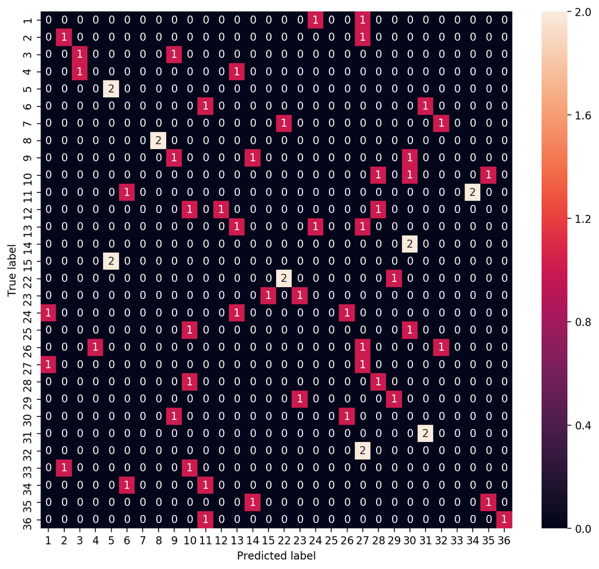

```
[0.27941176470588236,
 0.28888888888888886,
 0.2825396825396825,
 0.2696296296296296]
```

```python
clf_dtree2 = GridSearchCV(DecisionTreeClassifier(), dtree_parameters, cv=5, iid=True)
clf_dtree2.fit(X_train_red, y_train_red)

'''means = clf_svm.cv_results_['mean_test_score']
stds = clf_svm.cv_results_['std_test_score']
for mean, std, params in zip(means, stds, clf_svm.cv_results_['params']):
        print("%0.3f (+/-%0.03f) for %r"
              % (mean, std * 2, params))'''

print("\nBest parameters found:", clf_dtree2.best_params_)
#computing score on test set
clf_metrics("Decision tree", clf_dtree2.predict(X_test_red), y_test_red)
```

We can immediately notice that, as for the other classifiers, the accuracy of this model decreases a lot.

```python
title = "Learning Curve (Decision Tree with dimensionally reduced dataset)"
plot_learning_curve(clf_dtree2.best_estimator_, title, leaf_Xstd, leaf_y, cv=5)
```

[interactive chart not shown]

```python
f_importances = pd.DataFrame(clf_dtree2.best_estimator_.feature_importances_)
f_importances['attributes']=['PC1', 'PC2', 'PC3']
f_importances.sort_values(by=[0], ascending=False, inplace=True)

labels = f_importances['attributes'].values
fig = go.Figure([go.Bar(x=labels, y=f_importances[0].values)])
fig.update_layout(
    title=go.layout.Title(
        text="Feature importance in Decision Tree (dimensionally reduced dataset)",
        xref="paper",
        x=0
    ))
fig.show()
```

[interactive chart not shown]

As we should probably expect, the festure importance in this case are the principal components sorted by order of importance (from the one that expresses the most variance to the least).

#### Random forest

The **Random Forest** classifier creates a set of decision trees from randomly selected subset of training set. To classify a new object from an input vector, put the input vector down each of the trees in the forest. Each tree gives a classification, and we say the tree "votes" for that class. The forest chooses the classification having the most votes (over all the trees in the forest).

[figure not shown]

Now, we fit our model.

```python
randomforest_params = {
    'n_estimators': [100, 300, 500, 1000],
    'criterion': ['gini', 'entropy'],
    'max_depth': [25, 50, 75, 100],
    'max_features': ["sqrt", "log2", None],
    'n_jobs' : [4]
}
```

```
Best parameters found: {'criterion': 'gini', 'max_depth': 75, 'max_features': 'log2', 'n_estimators': 300, 'n_jobs': 4}

*** Decision tree scores ***
Accuracy:	 0.765
Recall:		 0.767
Precision:	 0.794
F1:		 0.745
```

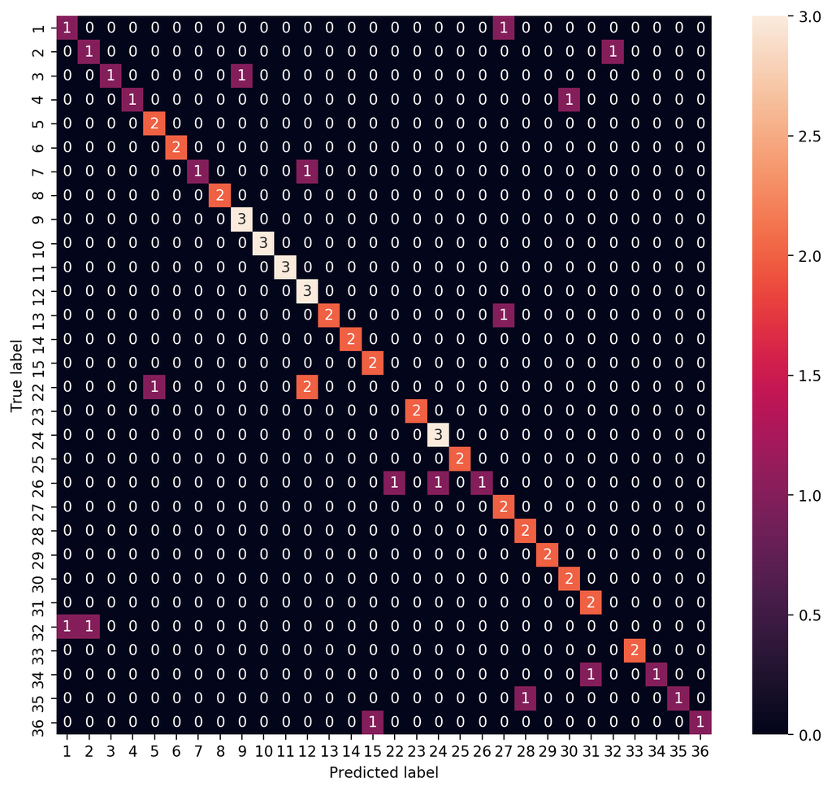

```python
clf_rforest = GridSearchCV(RandomForestClassifier(), randomforest_params, cv=5, iid=True)
clf_rforest.fit(X_train, y_train)

'''means = clf_svm.cv_results_['mean_test_score']
stds = clf_svm.cv_results_['std_test_score']
for mean, std, params in zip(means, stds, clf_svm.cv_results_['params']):
        print("%0.3f (+/-%0.03f) for %r"
              % (mean, std * 2, params))'''

print("\nBest parameters found:", clf_rforest.best_params_)
#computing score on test set
results_rforest = clf_metrics("Decision tree", clf_rforest.predict(X_test), y_test)
```

```python
title = "Learning Curve (Random forest)"
plot_learning_curve(clf_rforest.best_estimator_, title, leaf_Xstd, leaf_y, cv=5)
```

[interactive chart not shown]

The learning curve allows us to predict that, if we had more training data, the accuracy of the model would be better. It also seems that, compared to previous models, the curve has a greater slope (so, the model then learns faster).

```python
f_importances = pd.DataFrame(clf_rforest.best_estimator_.feature_importances_)
f_importances['attributes']=features[2:]
f_importances.sort_values(by=[0], ascending=False, inplace=True)

labels = f_importances['attributes'].values
fig = go.Figure([go.Bar(x=labels, y=f_importances[0].values)])
fig.update_layout(
    title=go.layout.Title(
        text="Feature importance in Random Forest",
        xref="paper",
        x=0
    ))
fig.show()
```

[interactive chart not shown]

The most important feature is *Solidity*, which in the decision tree was already in the second position.

### Comparison

We summarize here the results obtained by the various classifiers.

```python
results = []
results.append(results_knn)
results.append(results_svm)
results.append(results_dtree)
results.append(results_rforest)
names = ['KNN', 'SVM', 'Decision tree', 'Random forest']
resDF = pd.DataFrame(columns=['accuracy', 'recall', 'precision', 'f1'])
for i, name in zip(results, names):
    row = ["%.3f" % r for r in i]
    resDF.loc[name] = row
resDF
```

|  | accuracy | recall | precision | f1 |
| --- | --- | --- | --- | --- |
| KNN | 0.706 | 0.711 | 0.753 | 0.704 |
| SVM | 0.882 | 0.900 | 0.878 | 0.874 |
| Decision tree | 0.647 | 0.656 | 0.614 | 0.613 |
| Random forest | 0.765 | 0.767 | 0.794 | 0.745 |

We can see that SVM has the best performances, with Random Forest in second position.  
SVM is the classifier that has been able to adapt more quickly to the data, even though the data were relatively few in number.

### Conclusion

We have found that, for this relatively small multiclass dataset, the best classifier is SVM. Moreover, the attempt to train the models on a reduced dimensional dataset did not lead to an improvement in the performance of the models; probably, this would have led to an improvement if we had had hundreds or thousands of dimensions.

### References

- Box-plot:  
  https://www.khanacademy.org/math/statistics-probability/summarizing-quantitative-data/box-whisker-plots/a/box-plot-review  
  https://www.purplemath.com/modules/boxwhisk3.htm
- PCA:  
  https://en.wikipedia.org/wiki/Principal_component_analysis https://towardsdatascience.com/the-mathematics-behind-principal-component-analysis-fff2d7f4b643 http://www.sthda.com/english/wiki/print.php?id=206
- k-Fold Cross Validation:  
  https://scikit-learn.org/stable/modules/cross_validation.html#cross-validation
- measures:  
  https://nbviewer.jupyter.org/github/mbpr0/churnAnalysis/blob/master/ChurnFinal.ipynb#Exploration  
  https://www.coursera.org/lecture/python-machine-learning/multi-class-evaluation-1ugJR  
  https://scikit-learn.org/stable/modules/learning_curve.html#learning-curve
- Classifiers:  
  https://jeremykun.com/2017/06/05/formulating-the-support-vector-machine-optimization-problem/  
  https://en.wikipedia.org/wiki/Random_forest  
  https://www.stat.berkeley.edu/~breiman/RandomForests/cc_home.htm  
  http://www.globalsoftwaresupport.com/decision-tree-classifier-machine-learning/  
  https://medium.com/machine-learning-101/chapter-5-random-forest-classifier-56dc7425c3e1